# **EXPLANATORY DATA ANALYSIS OF LOAN ISSUANCE AND DEFAULT PATTERNS IN FINANCIAL INSTITUTION**

### **BUSINESS CONTEXT**

My client is a financial institution that specializes in consumer loans. Their portfolio includes diverse loan products such as personal loans, education loans, and business venture loans, medical loans and debt-consolidation to a wide range of customer demographics.

*What kind of data do they have?*

The datatset provided by the client contains information about customer loans, including customer demographics, loan details, and default status. It is a Loan Default Prediction Dataset. This data is well structured.

*Why do they need you as a data scientist?*

The organization needs me to help them in predicting loan default risk, by understanding customer profiles and loan characteristics that influence default risks, help them in strategic decision making by refining their credit policies, lending criteria, and marketing strategies.

My intervebntion as a data scientist will enable them to use their data to answer strategic business questions, showcase actionable insights, and enhance their financial operations.

**Data Source**

The data used in this analysis is from Kaggle, a public source and here is the link to my data source;

https://www.kaggle.com/datasets/prakashraushan/loan-dataset

**Business Questions**

1. Which age groups and income brackets should we prioritize for loan approvals in order to minimize default rates and hence improve business?
2. The business intends to conduct direct marketing by visiting different organizations and target specific employees to sell the loans to. Which category of employees should our sales-persons focus in in terms of the above features(Age and Income) in order to attract clients who are less likely to default?
3. In order to maximize profits, we want to find the best balance between interest rates and loan default, avoiding defaulters. Which loan grades offer that?
4. As we make future lending decisions, which loan purposes should be prioritized because of the lower likelihood of default?
5. Given the diverse nature of customers, should we consider employment duration when lending to our customers in the future? Why is that so?

### **IMPORTING THE LIBRARIES**

```python
import pandas as pd
import numpy as np
import matplotlib.pyplot as plt
import seaborn as sns
```

**DATA EXPLORATION AND CLEANING**

```python
data = pd.read_csv('/content/LoanDataset - LoansDatasest.csv.zip')
print("Shape of the data:", data.shape)
data.head(4)
```

```
Shape of the data: (32586, 13)
```

|  | customer_id | customer_age | customer_income | home_ownership | employment_duration | loan_intent | loan_grade | loan_amnt | loan_int_rate | term_years | historical_default | cred_hist_length | Current_loan_status |
| --- | --- | --- | --- | --- | --- | --- | --- | --- | --- | --- | --- | --- | --- |
| 0 | 1.0 | 22 | 59000 | RENT | 123.0 | PERSONAL | C | £35,000.00 | 16.02 | 10 | Y | 3 | DEFAULT |
| 1 | 2.0 | 21 | 9600 | OWN | 5.0 | EDUCATION | A | £1,000.00 | 11.14 | 1 | NaN | 2 | NO DEFAULT |
| 2 | 3.0 | 25 | 9600 | MORTGAGE | 1.0 | MEDICAL | B | £5,500.00 | 12.87 | 5 | N | 3 | DEFAULT |
| 3 | 4.0 | 23 | 65500 | RENT | 4.0 | MEDICAL | B | £35,000.00 | 15.23 | 10 | N | 2 | DEFAULT |

```python
#data.info()
```

The dataset consists of 13 features showing different information about customers. Both numerical and categorical data types are used here.

```python
#Checking the data types of the fearures
data.dtypes
```

|  | 0 |
| --- | --- |
| customer_id | float64 |
| customer_age | int64 |
| customer_income | object |
| home_ownership | object |
| employment_duration | float64 |
| loan_intent | object |
| loan_grade | object |
| loan_amnt | object |
| loan_int_rate | float64 |
| term_years | int64 |
| historical_default | object |
| cred_hist_length | int64 |
| Current_loan_status | object |

**dtype:** object

The customer_income is also an object instead of float type.

The cell below corrects the errors and show the new value for the features.

```python
"""We need to define a function to clean the data"""

def clean_currency(value):
    if isinstance(value, str):
        # Remove the currency symbol and commas
        value = value.replace('£', '').replace(',', '')
        return float(value)
    else:
        return value

data['loan_amnt'] = data['loan_amnt'].apply(clean_currency)
data['loan_amnt'].head(2)
```

|  | loan_amnt |
| --- | --- |
| 0 | 35000.0 |
| 1 | 1000.0 |

**dtype:** float64

```python
#chaging customer_income from string to int/float
data['customer_income'] = data['customer_income'].str.replace(',', '').astype(float)
data['customer_income'].dtypes
```

```
dtype('float64')
```

```python
data.describe().T
```

|  | count | mean | std | min | 25% | 50% | 75% | max |
| --- | --- | --- | --- | --- | --- | --- | --- | --- |
| customer_id | 32583.0 | 16289.497806 | 9405.919628 | 1.00 | 8144.5 | 16288.00 | 24433.50 | 32581.00 |
| customer_age | 32586.0 | 27.732769 | 6.360528 | 3.00 | 23.0 | 26.00 | 30.00 | 144.00 |
| customer_income | 32586.0 | 66076.371386 | 61980.289734 | 4000.00 | 38500.0 | 55000.00 | 79200.00 | 6000000.00 |
| employment_duration | 31691.0 | 4.790161 | 4.142746 | 0.00 | 2.0 | 4.00 | 7.00 | 123.00 |
| loan_amnt | 32585.0 | 9756.246739 | 21771.851498 | 500.00 | 5000.0 | 8000.00 | 12200.00 | 3500000.00 |
| loan_int_rate | 29470.0 | 11.011553 | 3.240440 | 5.42 | 7.9 | 10.99 | 13.47 | 23.22 |
| term_years | 32586.0 | 4.761738 | 2.471107 | 1.00 | 3.0 | 4.00 | 7.00 | 10.00 |
| cred_hist_length | 32586.0 | 5.804026 | 4.055078 | 2.00 | 3.0 | 4.00 | 8.00 | 30.00 |

The tabular representation of the data provides an insight about the numerical information of the organization. For example, we can see that the average age of the customers is 27, and that the bank charges an average interest rate of 11%.

**Missing Data**

The Code below checks the missing Data

```python
data.isna().sum()
```

|  | 0 |
| --- | --- |
| customer_id | 3 |
| customer_age | 0 |
| customer_income | 0 |
| home_ownership | 0 |
| employment_duration | 895 |
| loan_intent | 0 |
| loan_grade | 0 |
| loan_amnt | 1 |
| loan_int_rate | 3116 |
| term_years | 0 |
| historical_default | 20737 |
| cred_hist_length | 0 |
| Current_loan_status | 4 |

**dtype:** int64

We can see that the dataset contains some missing values in customer_id, employment_duration, loan_amnt, loan_int_rate, historical_default and Current_loan_status. Data cleaning is therefore necessary.

```python
#Filling the missing values in the dataset
data['customer_id'] = data['customer_id'].interpolate()
data['employment_duration'] = data['employment_duration'].fillna(data['employment_duration'].mean())
data['loan_amnt'] = data['loan_amnt'].fillna(data['loan_amnt'].mean())
data['loan_int_rate'] = data['loan_int_rate'].fillna(data['loan_int_rate'].mean())
data['historical_default'] = data['historical_default'].fillna(data['historical_default'].mode()[0])
data['Current_loan_status'] = data['Current_loan_status'].fillna(data['Current_loan_status'].mode()[0])
```

Various techniques have been used to resolve the NaN values.

Historical_default and Current_loan_status used mode since they are categorical columns. There are only 4 missing values for Current_loan_status, therefore not a very high impact. We will avoid using historical_default in our analysis due to large number of missing values.

The data is now clean as indicated below.

```python
data.isna().sum()
```

|  | 0 |
| --- | --- |
| customer_id | 0 |
| customer_age | 0 |
| customer_income | 0 |
| home_ownership | 0 |
| employment_duration | 0 |
| loan_intent | 0 |
| loan_grade | 0 |
| loan_amnt | 0 |
| loan_int_rate | 0 |
| term_years | 0 |
| historical_default | 0 |
| cred_hist_length | 0 |
| Current_loan_status | 0 |

**dtype:** int64

**Handling Duplicates**

```python
#Checking if there are duplicates
print('There are duplicated values:', data.duplicated().values.any())

#Number of the duplicated values
print('Number of duplicated values:', data.duplicated().sum())
```

```
There are duplicated values: True
Number of duplicated values: 6
```

```python
#Deleting the duplicates
data = data.drop_duplicates()
print('There are duplicated values:', data.duplicated().values.any())
print('Shape of data after dropping duplicates: ', data.shape)
```

```
There are duplicated values: False
Shape of data after dropping duplicates:  (32580, 13)
```

We can see that there were **6** duplicatated rows, and we dropped them. The duplicated() function which returns a Boolean series denoting duplicate rows confirms that there was no duplication any longer.

The shape of the dataset also changed when dropping took effect from **(32586, 13)** to **(32580, 13)**

```python
'''Checking the number of unique data'''
#For my Eyes only
data.nunique()
```

|  | 0 |
| --- | --- |
| customer_id | 32580 |
| customer_age | 62 |
| customer_income | 4295 |
| home_ownership | 4 |
| employment_duration | 37 |
| loan_intent | 6 |
| loan_grade | 5 |
| loan_amnt | 756 |
| loan_int_rate | 349 |
| term_years | 10 |
| historical_default | 2 |
| cred_hist_length | 29 |
| Current_loan_status | 2 |

**dtype:** int64

By applying the nunique() function which returns the number of distinct elements in each column, we can see that there are 4 types of home ownership, 5 different loan grades and 6 distinct intentions that customers have when borrowing loans.

### Exploratory Analysis

Nature of the data (Balanced or imbalanced)

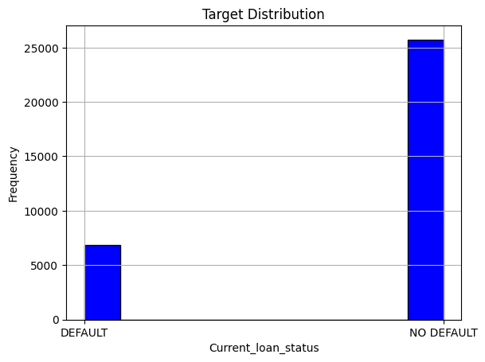

```python
#Balanced or imbalanced data
data['Current_loan_status'].hist(bins=10, color='blue', edgecolor='black')
plt.xlabel('Current_loan_status')
plt.ylabel('Frequency')
plt.title('Target Distribution')
plt.show()
```

The data is imbalanced. Since this is an EDA (Exploratoy Data Analysis), we do not need to balance the dataset so that we can use the original form to analyze patterns as they exist in the real world.

## **Corelation Analysis**

```python
'''Separating Categorical and numerical data'''
data_num = data.select_dtypes(include=['float64', 'int64'])
data_cat = data.select_dtypes(include=['object'])
```

```python
#A snippet of Categorical data
data_cat.head(2)
```

|  | home_ownership | loan_intent | loan_grade | historical_default | Current_loan_status |
| --- | --- | --- | --- | --- | --- |
| 0 | RENT | PERSONAL | C | Y | DEFAULT |
| 1 | OWN | EDUCATION | A | Y | NO DEFAULT |

```python
# A snippet of numerical data
data_num.head(2)
```

|  | customer_id | customer_age | customer_income | employment_duration | loan_amnt | loan_int_rate | term_years | cred_hist_length |
| --- | --- | --- | --- | --- | --- | --- | --- | --- |
| 0 | 1.0 | 22 | 59000.0 | 123.0 | 35000.0 | 16.02 | 10 | 3 |
| 1 | 2.0 | 21 | 9600.0 | 5.0 | 1000.0 | 11.14 | 1 | 2 |

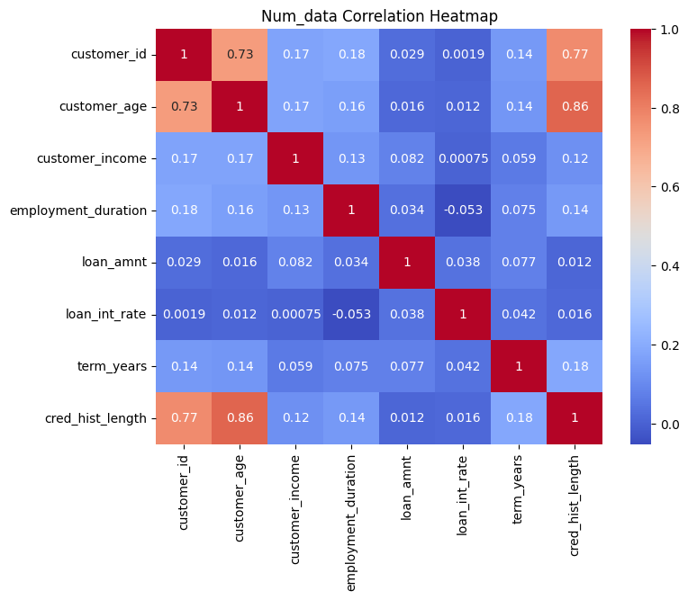

```python
#Showing the heatmap for numerical data
plt.figure(figsize=(8, 6))
sns.heatmap(data_num.corr(), annot=True, cmap='coolwarm')
plt.title('Num_data Correlation Heatmap')
plt.show()
```

# EXPLANATORY DATA ANALYSIS

# **QUESTIONS**

**QUESTION 4**

As we make future lending decisions, which loan purposes should be prioritized to help the business improve and why so?

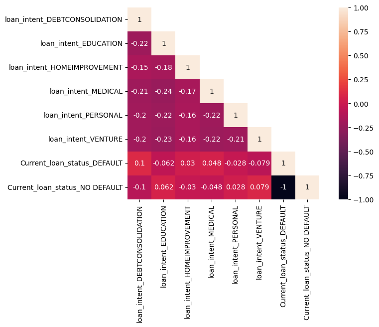

```python
#Correlation Heatmap between loan purpose and current loan status
#One hot encosing is necessary
data0 = data[['loan_intent', 'Current_loan_status']]
data_cat = pd.get_dummies(data0)
corr_mat = data_cat.corr()
mask = np.array(corr_mat)
mask[np.tril_indices_from(mask)] = False
fig = plt.gcf()
fig.set_size_inches(10, 5)
sns.heatmap(data_cat.corr(), mask=mask, square = True, annot=True, cbar = True)
plt.show()
```

<->

<->

**QUESTION 1**

To expand our market base through marketing, which age groups and income brackets should we prioritize for loan approvals in order to minimize default rates and hence improve the business?

```python
bins = [15, 20, 30, 40, 50, 60]  # Define age bins
labels = ['<20', '20-29', '30-39', '40-49', '>50']  # Labels for bins

data['Age Group'] = pd.cut(data['customer_age'], bins=bins, labels=labels, right=True)

'''Might delete this later..'''
# Count the number of customers in each bin
age_distribution = data['Age Group'].value_counts().sort_index()
age_distribution
```

| Age Group | count |
| --- | --- |
| <20 | 15 |
| 20-29 | 24809 |
| 30-39 | 6260 |
| 40-49 | 1205 |
| >50 | 218 |

**dtype:** int64

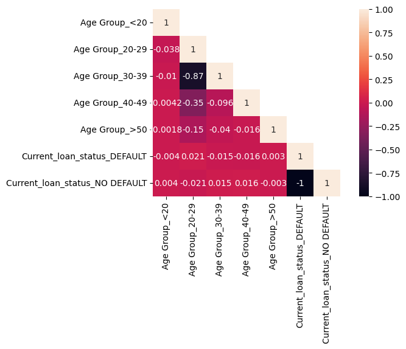

```python
'''Plotting correlation heatmap between age group and Current_loan_status'''
data1 = data[['Age Group', 'Current_loan_status']]
data_cat = pd.get_dummies(data1)
corr_mat = data_cat.corr()
mask = np.array(corr_mat)
mask[np.tril_indices_from(mask)] = False
fig = plt.gcf()
fig.set_size_inches(8, 4)
sns.heatmap(data_cat.corr(), mask=mask, square = True, annot=True, cbar = True)
plt.show()
```

From the heatmap above, we can see that age group does not strongly relate with the loan status. However:

The highest positive correlation (0.021) is with the 20-29 age group, suggesting a slightly higher risk of default compared to others.

The highest negative correlation (-0.016) is with the 40-49 age group, implying a slightly lower likelihood of default.

<->

<->

```python
#Creating bins for customer income
bins = [20000, 40000, 60000, 80000, 100000, 120000]  # Define age bins
labels = ['<20k', '20k-40k', '40k-60k', '60k-80k', '>80k']  # Labels for bins

data['Income Category'] = pd.cut(data['customer_income'], bins=bins, labels=labels, right=True)

'''Might delete this later..'''
# Count the number of customers in each bin
age_distribution = data['Income Category'].value_counts().sort_index()
age_distribution
```

| Income Category | count |
| --- | --- |
| <20k | 8106 |
| 20k-40k | 9448 |
| 40k-60k | 6204 |
| 60k-80k | 3443 |
| >80k | 1799 |

**dtype:** int64

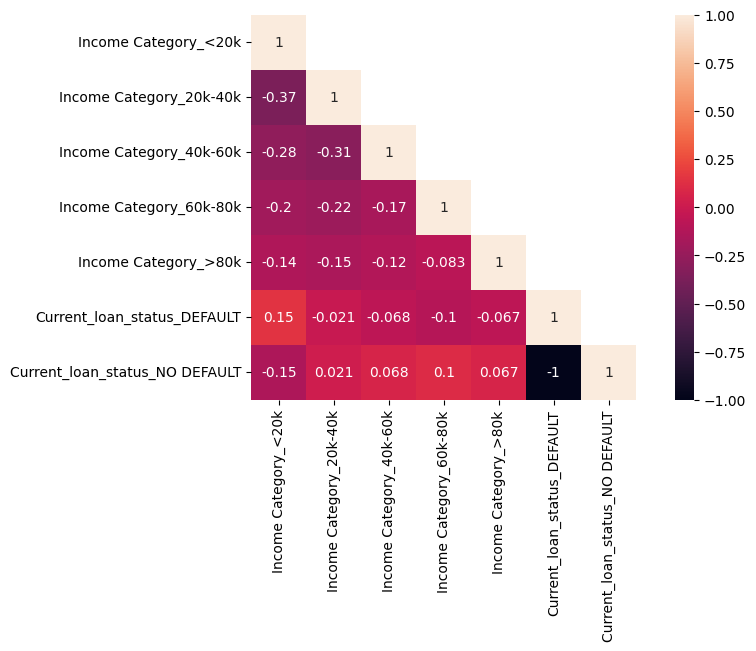

```python
'''Plotting correlation heatmap between Income category and Current_loan_status'''
data2 = data[['Income Category', 'Current_loan_status']]
data_cat = pd.get_dummies(data2)
corr_mat = data_cat.corr()

mask = np.array(corr_mat)
mask[np.tril_indices_from(mask)] = False
fig = plt.gcf()
fig.set_size_inches(10, 5)
sns.heatmap(data_cat.corr(), mask=mask, square = True, annot=True, cbar = True)
plt.show()
```

<->

<->

**QUESTION 2**

The business intends to conduct direct marketing by visiting different organizations and target specific employees to sell the loans to. Which category of employees should our sales-persons focus on in terms of the above features (Age and Income) in order to attract clients who are less likely to default?

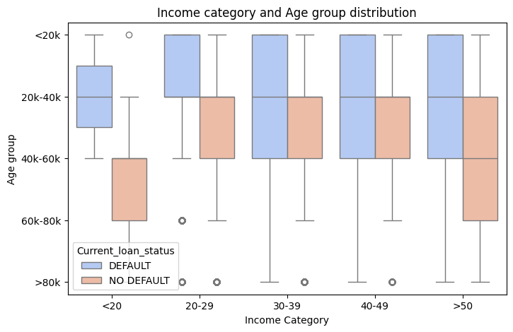

```python
'''Income and Age distribution with default status'''

data5 = data[['Income Category', 'Age Group', 'Current_loan_status']]
plt.figure(figsize=(8, 5))
sns.boxplot(x="Age Group", y="Income Category", data = data5,  palette="coolwarm", hue = 'Current_loan_status')
plt.title("Income category and Age group distribution")
plt.xlabel("Income Category")
plt.ylabel("Age group")
plt.show()
```

This plot shows the best combination of age group and income vis a vis loan status.

From the boxplot above, we can see that:

The salespersons should therefore target employees aged 40 and above, earning at least 60k, as they present the best balance of manageable default risk and loan profitability.

<->

<->

**QUESTION 3**

In order to maximize profitability, we want to find the best balance between high interest rates and low default rates. Which loan grades offer that?

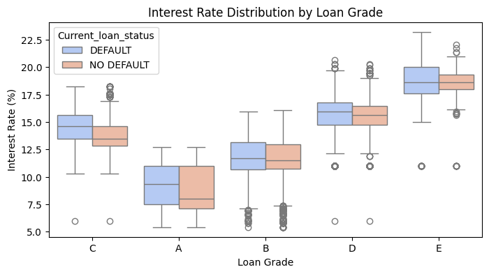

```python
# Interest Rate Distribution by Loan Grade
data3 = data[['loan_grade', 'loan_int_rate', 'Current_loan_status']]
plt.figure(figsize=(8, 4))
sns.boxplot(x="loan_grade", y="loan_int_rate", data=data3, palette="coolwarm", hue='Current_loan_status')
plt.title("Interest Rate Distribution by Loan Grade")
plt.xlabel("Loan Grade")
plt.ylabel("Interest Rate (%)")
plt.show()
```

To maximize profitability, we need high interest rates with manageable default risk. From the boxplot above, we can see that:

**Grade C** offers a moderate interest rate and has a lower default, not as extreme as Grades D & E. The grade therefore has the highest potential to generate income to the organization.

Grade B is another safe option, offering lower defaults but also lower interest rates and therefore not much profit to the business

The organization should therefore lend more to individuals in Grade C.

<->

<->

**QUESTION 5**

Given the diverse nature of customers, should we consider employment duration when lending to our customers in the future? Why is that so?

```python
#Defining bins for employment duration
bins = [0, 1, 3, 6, 9, 12, 15]  # Define age bins
labels = ['0', '1-2', '3-5', '6-8', '9-11', '>12']  # Labels for bins

data['Duration'] = pd.cut(data['employment_duration'], bins=bins, labels=labels, right=True)

# Count the number of customers in each bin
age_distribution = data['Duration'].value_counts().sort_index()
age_distribution
```

| Duration | count |
| --- | --- |
| 0 | 2915 |
| 1-2 | 7305 |
| 3-5 | 9380 |
| 6-8 | 5250 |
| 9-11 | 2011 |
| >12 | 999 |

**dtype:** int64

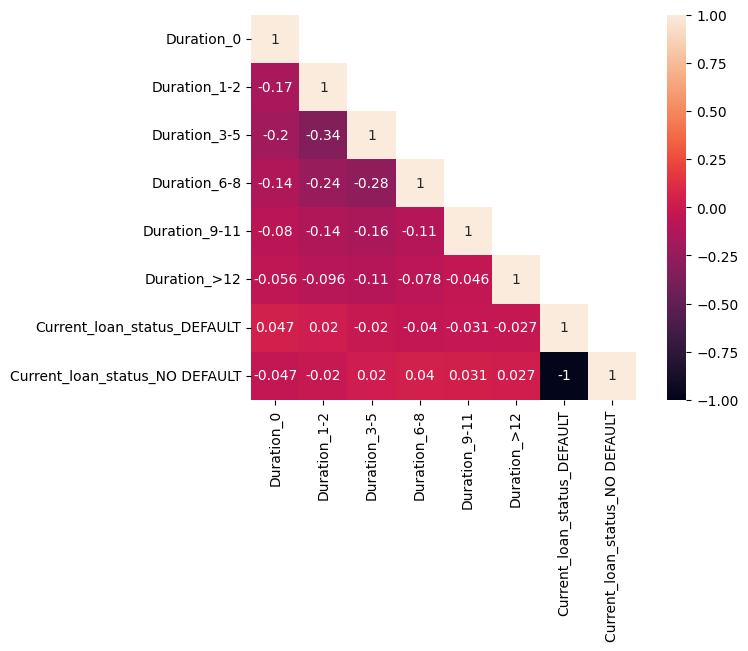

```python
'''Plotting correlation heatmap between Income category and Current_loan_status'''

data6 = data[['Duration', 'Current_loan_status']]
data_cat = pd.get_dummies(data6)
corr_mat = data_cat.corr()

mask = np.array(corr_mat)
mask[np.tril_indices_from(mask)] = False
fig = plt.gcf()
fig.set_size_inches(8, 5)
sns.heatmap(data_cat.corr(), mask=mask, square = True, annot=True, cbar = True)
plt.show()
```

From the correlation heatmap above, we observe that:

The correlation between longer employment duration (e.g. >12) and loan default status is weakly negative or near zero, meaning longer employment does not strongly predict default.

Shorter employment durations (e.g. below 2 years) show a slightly positive correlation with defaults, suggesting that customers with short employment durations might be more likely to default.

Since employment duration provides some indication of financial stability, customers with longer employment durations may be more reliable borrowers. Therefore, employment duration should be considered when lending to customers in the future.

<->

<->

**Final Discussion and Conclusion**

### Strengths and Limitations of the Explanatory Data Analysis (EDA)

**Strengths:**

1. The analysis provided is evidence-based or data driven.It answers the business questions using statistical methods and visualizations, enabling more informed decision-making.
2. The use of histograms and other visualization techniques allowed for an intuitive understanding of key patterns and trends.
3. The insights relevant in adressing the financial institution’s concerns, such as loan approvals, default risk, and target customers etc

**Limitations:**

1. The dataset may not be fully representative of all future borrowers, which could limit the generalizability of the results.
2. The analysis did not incorporate external economic conditions, regulatory changes, or industry trends that may impact loan defaults.

## Data-Driven Recommendations

The financial institution can enhance lending decisions, maximize profitability, and minimize risk, leading to a stronger and more sustainable business model if they follow the provided insights above